# VIQ - Laboratorio 3

8 Aprile 2021

### Obiettivi

1. Apprendere le basi per la programmazione in R
2. Manipolare data set

### Strumento

R ed RStudio

### Dataset

Utilizziamo il dataset pubblico sugli omicidi tramite armi da fuoco negli USA per il 2010. Che è incluso nella libreria `dslabs` (da installare se non già presente) e da importare con la funzione `library()`.

Per poter usare il dataset è necessario utilizzare il comando `data(murders)` che include nell’environment il data frame omonimo con tutti i dati.

Le operazioni precedenti sono già compiute nel seguente *chunk*:

```r
if(! "dslabs" %in% installed.packages() ){
  install.packages("dslabs")
}
library(dslabs)
data(murders) # load the US murders dataset
```

Ulteriori informazioni possono essere ottenute (dopo aver importato il package) con il comando `? murders` o cercando `murders` nel pannello di help.

È possibile creare un data frame anche indicando esplicitamente i valori delle diverse colonne, usando la funzione `data.frame()`:

```r
temp <- c(35, 88, 42, 84, 81, 30)
city <- c("Beijing", "Lagos", "Paris",
          "Rio de Janeiro", "San Juan", "Toronto")
city_temps <- data.frame(name = city, temperature_F = temp)
```

### Procedura

Per ogni parte di esercizio questo documento R-Markdown contiene un frammento (*chunk*) di codice R che deve essere completato secondo le indicazioni.

Dopo aver scritto il codice R è possibile verificare il funzionamento cliccando sulla freccia verde in alto a sinistra del blocco.

**Attenzione**: le varie parti degli esercizi possono dipendere da quelli precedenti e sicuramente dipendono dal blocco *setup* qui sopra che deve essere eseguito prima di tutti.

In alternativa è possibile utilizzare il pulsante in alto nel pannello dell’editor: il comando esegue tutti i *chunk*, inserisce il risultato nel documento e genera il file HTML.

## ESERCIZIO 1 - Uso dei data frame

### Data frames

I data frame (`data.frame`) sono lo strumento base in cui vengono memorizzati dati in formato tabulare provenienti da diverse fonti.

Buona parte delle elaborazioni ed analisi partono da dati memorizzatin in data frame (o loro estensioni).

Stampare la porzione iniziale del dataset utilizzando la funzione `head()`

```r
# TODO: inserire il codice per stampare la porzione iniziale del dataset
head(city_temps)
```

```
##             name temperature_F
## 1        Beijing            35
## 2          Lagos            88
## 3          Paris            42
## 4 Rio de Janeiro            84
## 5       San Juan            81
## 6        Toronto            30
```

È possibile accedere alle singole colonne del dataframe utilizzando l’operatore di accesso `$` (o in alternativa quello di estrazione `[[]]` ), entrambi restituiscono un vettore.

```r
murders
```

```
##                   state abb        region population total
## 1               Alabama  AL         South    4779736   135
## 2                Alaska  AK          West     710231    19
## 3               Arizona  AZ          West    6392017   232
## 4              Arkansas  AR         South    2915918    93
## 5            California  CA          West   37253956  1257
## 6              Colorado  CO          West    5029196    65
## 7           Connecticut  CT     Northeast    3574097    97
## 8              Delaware  DE         South     897934    38
## 9  District of Columbia  DC         South     601723    99
## 10              Florida  FL         South   19687653   669
## 11              Georgia  GA         South    9920000   376
## 12               Hawaii  HI          West    1360301     7
## 13                Idaho  ID          West    1567582    12
## 14             Illinois  IL North Central   12830632   364
```

[output cut: 37 more lines]

Si ottenga il contenuto della colonna *abb* utilizzando i due operatori.

```r
## TODO scrivere il codice per ottenere il contenuto della colonna *abb* utilizzando i due operatori.
murders$abb
```

```
##  [1] "AL" "AK" "AZ" "AR" "CA" "CO" "CT" "DE" "DC" "FL" "GA" "HI" "ID" "IL" "IN"
## [16] "IA" "KS" "KY" "LA" "ME" "MD" "MA" "MI" "MN" "MS" "MO" "MT" "NE" "NV" "NH"
## [31] "NJ" "NM" "NY" "NC" "ND" "OH" "OK" "OR" "PA" "RI" "SC" "SD" "TN" "TX" "UT"
## [46] "VT" "VA" "WA" "WV" "WI" "WY"
```

```r
murders[["abb"]]
```

```
##  [1] "AL" "AK" "AZ" "AR" "CA" "CO" "CT" "DE" "DC" "FL" "GA" "HI" "ID" "IL" "IN"
## [16] "IA" "KS" "KY" "LA" "ME" "MD" "MA" "MI" "MN" "MS" "MO" "MT" "NE" "NV" "NH"
## [31] "NJ" "NM" "NY" "NC" "ND" "OH" "OK" "OR" "PA" "RI" "SC" "SD" "TN" "TX" "UT"
## [46] "VT" "VA" "WA" "WV" "WI" "WY"
```

Per capire quali i tipi di dato delle 5 colonne è possibile usare la funzione `class()` applicata alle singole colonne.

```r
# TODO: inserire il codice per ottenere il tipo delle colonne e poi avere il sommario del data.frame
class(murders$abb)
```

```
## [1] "character"
```

```r
class(murders$state)
```

```
## [1] "character"
```

```r
class(murders$region)
```

```
## [1] "factor"
```

```r
class(murders$population)
```

```
## [1] "numeric"
```

```r
class(murders$total)
```

```
## [1] "numeric"
```

La colonna *region* a differenza delle due precedenti ha come tipo `factor`. Dato un fattore è possibile conoscere i livelli (overro i possibili valori) tramite la funzione `levels()`.

Si stampino i livelli della colonna *regione* ed il minimo e massimo del numero di omicidi (colonna *total*).

```r
# TODO: stampare i livelli della colonna *regione* ed il minimo e massimo del numero di omicidi (colonna *total*).
levels(murders$region)
```

```
## [1] "Northeast"     "South"         "North Central" "West"
```

```r
min(murders$total)
```

```
## [1] 2
```

```r
max(murders$total)
```

```
## [1] 1257
```

Per effettuare il conteggio dei diversi valori di una colonna è possibile utilizzare la funzione `table()`

Contare le frequnze dei diversi livelli della colonna *region*.

```r
# TODO: inserire il codice per calcolare le frequenze dei livelli di region
table(murders$region)
```

```
##
##     Northeast         South North Central          West
##             9            17            12            13
```

Si contino le frequnze dei diversi livelli della colonna *region*, esprimendoli anche come proporzioni (somma = 1) e come percentuale (somma = 100%).

```r
# TODO: inserire il codice per calcolare le frequenze dei livelli di region ed esprimerli anche in percentuale.
c <- table(murders$region)
somma <- sum(c)
prop <- c/somma
perc <- prop*100
print(prop)
```

```
##
##     Northeast         South North Central          West
##     0.1764706     0.3333333     0.2352941     0.2549020
```

```r
print(perc)
```

```
##
##     Northeast         South North Central          West
##      17.64706      33.33333      23.52941      25.49020
```

Per avere una visione d’insieme è possibile utilizzare la funzione `summary()` che stampa, oltre al tipo della colonna, alcune informazioni di riepilogo.

```r
# TODO: inserire il codice per avere il sommario del data.frame murders
summary(murders)
```

```
##     state               abb                      region     population
##  Length:51          Length:51          Northeast    : 9   Min.   :  563626
##  Class :character   Class :character   South        :17   1st Qu.: 1696962
##  Mode  :character   Mode  :character   North Central:12   Median : 4339367
##                                        West         :13   Mean   : 6075769
##                                                           3rd Qu.: 6636084
##                                                           Max.   :37253956
##      total
##  Min.   :   2.0
##  1st Qu.:  24.5
##  Median :  97.0
##  Mean   : 184.4
##  3rd Qu.: 268.0
##  Max.   :1257.0
```

### Ordinamento

Ordinare la *“variabile”* (o colonna) *population* dal valore più piccolo al più grande

```r
# TODO: interire il codice necesario
sort(murders$population) #aggiungo TRUE per il descescente
```

```
##  [1]   563626   601723   625741   672591   710231   814180   897934   989415
##  [9]  1052567  1316470  1328361  1360301  1567582  1826341  1852994  2059179
## [17]  2700551  2763885  2853118  2915918  2967297  3046355  3574097  3751351
## [25]  3831074  4339367  4533372  4625364  4779736  5029196  5303925  5686986
## [33]  5773552  5988927  6346105  6392017  6483802  6547629  6724540  8001024
## [41]  8791894  9535483  9883640  9920000 11536504 12702379 12830632 19378102
## [49] 19687653 25145561 37253956
```

```r
# TODO: interire il codice necesario
or <- order( - murders$population)
murders[or, c("state", "population")]
```

```
##                   state population
## 5            California   37253956
## 44                Texas   25145561
## 10              Florida   19687653
## 33             New York   19378102
## 14             Illinois   12830632
## 39         Pennsylvania   12702379
## 36                 Ohio   11536504
## 11              Georgia    9920000
## 23             Michigan    9883640
## 34       North Carolina    9535483
## 31           New Jersey    8791894
## 47             Virginia    8001024
## 48           Washington    6724540
## 22        Massachusetts    6547629
```

[output cut: 37 more lines]

Ordinare l’intero data frame sulla base del numero di omicidi (*total*)

```r
# TODO: interire il codice necesario
or <- order(murders$total)
murders[or,]
```

```
##                   state abb        region population total
## 46              Vermont  VT     Northeast     625741     2
## 35         North Dakota  ND North Central     672591     4
## 30        New Hampshire  NH     Northeast    1316470     5
## 51              Wyoming  WY          West     563626     5
## 12               Hawaii  HI          West    1360301     7
## 42         South Dakota  SD North Central     814180     8
## 20                Maine  ME     Northeast    1328361    11
## 13                Idaho  ID          West    1567582    12
## 27              Montana  MT          West     989415    12
## 40         Rhode Island  RI     Northeast    1052567    16
## 2                Alaska  AK          West     710231    19
## 16                 Iowa  IA North Central    3046355    21
## 45                 Utah  UT          West    2763885    22
## 49        West Virginia  WV         South    1852994    27
```

[output cut: 37 more lines]

## ESERCIZIO 2 - Operazioni sui data frame

### Aritmetica tra vettori

A partire dal data frame sulle temperature (`city_temps`), calcolare le temperature in Celsius a partire da quelle espresse in Fahrenheit.

La formula di conversione è:

$$C = \frac{5}{9} \cdot ( F - 32 )$$

```r
# TODO: interire il codice necesario
celsius <- (5/9) * (city_temps$temperature_F -32)
city_temps$temperature_C <- celsius
city_temps
```

```
##             name temperature_F temperature_C
## 1        Beijing            35      1.666667
## 2          Lagos            88     31.111111
## 3          Paris            42      5.555556
## 4 Rio de Janeiro            84     28.888889
## 5       San Juan            81     27.222222
## 6        Toronto            30     -1.111111
```

Usando la stessa conversione aggiungere una colonna al data frame delle temperature con le temperature in Celcius. Può essere utile un arrotondamento?

Suggerimento: l’operatore di accesso permette anche di assegnare a nuove colonne.

```r
# TODO: interire il codice necesario
celsius <- (5/9) * (city_temps$temperature_F -32)
city_temps$temperature_C <- celsius
c <- round(city_temps$temperature_C, 3)
city_temps$temperature_C <- c
city_temps
```

```
##             name temperature_F temperature_C
## 1        Beijing            35         1.667
## 2          Lagos            88        31.111
## 3          Paris            42         5.556
## 4 Rio de Janeiro            84        28.889
## 5       San Juan            81        27.222
## 6        Toronto            30        -1.111
```

Calcolare (ed aggiungere come nuova colonna *rate*) il tasso di omicidi ogni 100 000 persone nel data frame degli omicidi e mostrare il data frame aggiornato

```r
# TODO: interire il codice necesario
murders$rate <- round(((murders$total*100000)/murders$population), 2)
murders
```

```
##                   state abb        region population total  rate
## 1               Alabama  AL         South    4779736   135  2.82
## 2                Alaska  AK          West     710231    19  2.68
## 3               Arizona  AZ          West    6392017   232  3.63
## 4              Arkansas  AR         South    2915918    93  3.19
## 5            California  CA          West   37253956  1257  3.37
## 6              Colorado  CO          West    5029196    65  1.29
## 7           Connecticut  CT     Northeast    3574097    97  2.71
## 8              Delaware  DE         South     897934    38  4.23
## 9  District of Columbia  DC         South     601723    99 16.45
## 10              Florida  FL         South   19687653   669  3.40
## 11              Georgia  GA         South    9920000   376  3.79
## 12               Hawaii  HI          West    1360301     7  0.51
## 13                Idaho  ID          West    1567582    12  0.77
## 14             Illinois  IL North Central   12830632   364  2.84
```

[output cut: 37 more lines]

Qual’è la media del tasso di omicidi?

```r
# TODO: interire il codice necesario
mean(murders$rate)
```

```
## [1] 2.778824
```

È possibile utilizzare la funzione `fivenum()` per calcolare la sintesi in 5 numeri (minimo, 1^o quartile, mediana, 3^o quartile, massimo) dei dati di una colonna. Quali sono i 5 numeri che sintetizzano la collona *rate*?

```r
# TODO: interire il codice necesario
five <- fivenum(murders$rate)
five
```

```
## [1]  0.320  1.250  2.690  3.385 16.450
```

### Indicatori

Quanti sono gli stati in cui il tasso di omicidi è minore è uguale al primo quartile (calcolato qui sopra)?

```r
# TODO: interire il codice necesario
minus <- which( murders$rate <= five[2] )
print(length(minus))
```

```
## [1] 13
```

Usando un vettore indicatore, selezionare la porzione del dataframe che corrisponde agli stati nel primo quartile per tasso di omicidi.

```r
# TODO: interire il codice necesario
murders[minus,]
```

```
##            state abb        region population total rate
## 12        Hawaii  HI          West    1360301     7 0.51
## 13         Idaho  ID          West    1567582    12 0.77
## 16          Iowa  IA North Central    3046355    21 0.69
## 20         Maine  ME     Northeast    1328361    11 0.83
## 24     Minnesota  MN North Central    5303925    53 1.00
## 27       Montana  MT          West     989415    12 1.21
## 30 New Hampshire  NH     Northeast    1316470     5 0.38
## 35  North Dakota  ND North Central     672591     4 0.59
## 38        Oregon  OR          West    3831074    36 0.94
## 42  South Dakota  SD North Central     814180     8 0.98
## 45          Utah  UT          West    2763885    22 0.80
## 46       Vermont  VT     Northeast     625741     2 0.32
## 51       Wyoming  WY          West     563626     5 0.89
```

Riportare i dati relativi agli stati nella regione `"West"` che si trovano nel primo quartile per tasso di omicidi.

Suggerimento: costruire un vettore indicatore combinando con operatori logici le due condizioni

```r
# TODO: interire il codice necesario
minew <- which( murders$region == "West", TRUE )
minus <- which( murders$rate <= five[2], TRUE )
common <- 1
t <- 1
for( i in 1:length(minew) ){
  for( j in 1:length(minus) )
    if(minus[j] == minew[i]){
      common[t] <- minew[i]
      print(common[t])
      t <- t+1
      break
    }
}
```

```
## [1] 12
## [1] 13
## [1] 27
## [1] 38
## [1] 45
## [1] 51
```

```r
murders[common, ]
```

```
##      state abb region population total rate
## 12  Hawaii  HI   West    1360301     7 0.51
## 13   Idaho  ID   West    1567582    12 0.77
## 27 Montana  MT   West     989415    12 1.21
## 38  Oregon  OR   West    3831074    36 0.94
## 45    Utah  UT   West    2763885    22 0.80
## 51 Wyoming  WY   West     563626     5 0.89
```

```r
minew2 <- murders[which(murders$region == "West" & murders$rate <= five[2], TRUE),]
minew2
```

```
##      state abb region population total rate
## 12  Hawaii  HI   West    1360301     7 0.51
## 13   Idaho  ID   West    1567582    12 0.77
## 27 Montana  MT   West     989415    12 1.21
## 38  Oregon  OR   West    3831074    36 0.94
## 45    Utah  UT   West    2763885    22 0.80
## 51 Wyoming  WY   West     563626     5 0.89
```

Usare l’operatore `%in%`per creare un vettore indicatore che indentifichi gli stati che hanno come abbreviazionie MA, ME, MI, MO, MU. E calcolare il numero di stati identificati.

```r
# TODO: interire il codice necesario
states <- murders$abb %in% c("MA", "ME", "MI", "MO", "MU")
length(murders$state[states])
```

```
## [1] 4
```

Usare lo stesso operatore per capire quali tra le abbreviazioni corrispondono ad abbreviazioni reali e riportarne l’elenco.

```r
# TODO: interire il codice necesario
murders$abb[states]
```

```
## [1] "ME" "MA" "MI" "MO"
```

## Fattori

La funzione `cut()` permette di suddividere valori numerici in intervalli (dati gli estremi, inferiore escluso) ed associare un valore a ciuscun intervallo. Il risultato è un vettore di *factor*.

```r
## Esempio di uso di cut()
x <- runif(50,1,31) # 50 numeri casuali tra 0 e 31
rating <- cut(x, c(0,18,30,31),c("Ins","Suff","Lode"))
names(x) <- rating
x
```

```
##       Ins       Ins       Ins       Ins       Ins       Ins      Suff       Ins
## 13.110533  8.800650  8.692701  1.859546 13.902549  3.461948 23.137930  8.837613
##       Ins       Ins       Ins       Ins       Ins       Ins       Ins       Ins
## 10.953084 10.507336 15.119462  7.484922  6.852037 15.833372  3.826866 12.622963
##       Ins       Ins       Ins       Ins      Suff       Ins       Ins      Suff
##  8.998328 14.633417  7.527342  6.116858 26.621320  1.170836 11.229693 20.291951
##       Ins       Ins       Ins       Ins      Suff      Suff       Ins       Ins
## 17.189098 15.442989 12.423876 16.477490 23.142610 19.505616  3.816884  9.537279
##       Ins       Ins      Suff      Suff       Ins       Ins      Suff       Ins
## 15.669397 11.658851 22.395993 18.313263 14.864674 17.826117 18.593852 15.868063
##      Suff       Ins      Suff      Suff      Suff      Suff       Ins      Suff
## 22.649681 12.681587 20.351231 25.668334 21.177492 20.436456 15.107005 25.801926
##       Ins      Lode
## 10.524894 30.070300
```

Associare al tasso di omicidi un livello (basso, medio, alto) corrispondente agli intervalli (0,1], (1,3], (3,20], e aggingere tale classificazione come nuova colonna *rating*.

```r
# TODO: interire il codice necesario
murders$rating <- cut(murders$rate, c(0,1,3,20), c("Basso", "Medio", "Alto"))
murders
```

```
##                   state abb        region population total  rate rating
## 1               Alabama  AL         South    4779736   135  2.82  Medio
## 2                Alaska  AK          West     710231    19  2.68  Medio
## 3               Arizona  AZ          West    6392017   232  3.63   Alto
## 4              Arkansas  AR         South    2915918    93  3.19   Alto
## 5            California  CA          West   37253956  1257  3.37   Alto
## 6              Colorado  CO          West    5029196    65  1.29  Medio
## 7           Connecticut  CT     Northeast    3574097    97  2.71  Medio
## 8              Delaware  DE         South     897934    38  4.23   Alto
## 9  District of Columbia  DC         South     601723    99 16.45   Alto
## 10              Florida  FL         South   19687653   669  3.40   Alto
## 11              Georgia  GA         South    9920000   376  3.79   Alto
## 12               Hawaii  HI          West    1360301     7  0.51  Basso
## 13                Idaho  ID          West    1567582    12  0.77  Basso
## 14             Illinois  IL North Central   12830632   364  2.84  Medio
```

[output cut: 37 more lines]

Calcolare le frequenze dei diversi rating:

```r
# TODO: interire il codice necesario
Freq <- table(murders$rating)
Freq
```

```
##
## Basso Medio  Alto
##    12    20    19
```

## ESERCIZIO 3 - Funzioni

### Temperature

La formula per convertire una temperatura Fahrenheit in un Celsius è:

$$C = \frac{5}{9} \cdot ( F - 32 )$$

Scrivere la funzione `f_to_c()` che riceve una temperature °F e la converte in °C.

```r
# TODO: interire il codice necesario
f_to_c <- function(f){
  c <- (5/9)*(f-32)
  return (c)
}
```

Verifica:

```r
if( exists("f_to_c") ){
  print( f_to_c(61) )
}
```

```
## [1] 16.11111
```

La funzione è vettorizzata? Ovvero funziona se applicata ad un vettore invece che ad una singolo valore? Se non lo è modificarla in modo che lo sia.

Verifica:

```r
temperature <- c(82,61,32)
if( exists("f_to_c") ){
  print( f_to_c( temperature ) )
}
```

```
## [1] 27.77778 16.11111  0.00000
```

Scrivere la funzione `c_to_f()` che faccia la conversione inversa.

```r
# TODO: interire il codice necesario
c_to_f <- function(c){
  f <- (9/5)*c + 32
  return (f)
}
```

Verifica:

```r
temperature <- c(28,16,0)
if( exists("c_to_f") ){
  print( c_to_f( temperature ) )

  print( f_to_c( c_to_f( temperature ) ) )
}
```

```
## [1] 82.4 60.8 32.0
## [1] 28 16  0
```

Scrivere una funzione `temp_conv()` che riceve due parametri (opzionali) `f` e `c` che contengono i valori delle temperature rispettivamente in °F e °C e partendo dal valore fornito calcoli e stampi quello mancante.

Suggerimento: utilizzare dei valori di default `NA` per poter facilmente rilevare quale parametro non è passato.

```r
# TODO: interire il codice necesario
temp_conv <- function(c=NA, f=NA){
  if(all(is.na(c))){
    return (f_to_c(f))
  }
  if(is.na(f)){
    return (c_to_f(c))
  }
}
```

Verifica:

```r
if(exists("temp_conv")){
  print(temp_conv( f=c(82)))
  print(temp_conv( c=c(28)))
}
```

```
## [1] 27.77778
## [1] 82.4
```

Anche questa funzione è vettorizzata?

Suggerimento: quando si fa un test su un vettore viene utilizzato un solo elemento e questo causa un *warning*. Per risolvere il problema è possibile fare il test su un solo elemento (ad es. il primo) oppure verificare che il test risulti vero su tutti gli elementi (funzione `all()`)

Verifica:

```r
if(exists("temp_conv")){
  print(temp_conv( f=c(82,61,32)))
  print(temp_conv( c=c(28,16,0)))
}
```

```
## [1] 27.77778 16.11111  0.00000
## [1] 82.4 60.8 32.0
```

## Fibonacci

```r
# TODO: interire il codice necesario
fibonacci <- function(n){
  fib <- 1:n
  fib[1] <- 1
  fib[2] <- 1
  for(i in 3:n ){
    fib[i] <- fib[i-1] + fib[i-2]
  }
  return (fib)
}
```

Verifica:

```r
# specificare un intero n:
n <- 7
if( exists("fibonacci") ){
  print( fibonacci(n) )
}
```

```
## [1]  1  1  2  3  5  8 13
```

È possibile fare una soluzione iterativa (basata su un ciclo che ad ogni iterazione calcola un nuovo elemento), oppure una ricorsiva che richiama se stessa per calcolare i valori precedenti.

Provare a sviluppare entrambe.

Versione ricorsiva

```r
# TODO: interire il codice necessario
successione_Fibonacci <- function(n, fib = NA){
  if(all(is.na(fib))){
    fib <- 1:n
  }
  if(n == 1 | n == 2){
    fib[n] <- 1
    return (fib)
  }

  fib <- successione_Fibonacci(n-1, fib)
  fib <- successione_Fibonacci(n-2, fib)

  fib[n] <- fib[n-1] + fib[n-2]
  return (fib)

}
```

Verifica:

```r
# specificare un intero n:
n <- 7
if( exists("successione_Fibonacci") ){
  print( successione_Fibonacci(n) )
}
```

```
## [1]  1  1  2  3  5  8 13
```

# ESERCIZIO 4 - Grafici di base

Utilizzare la funzione `plot()` per costruire un grafico a dispersione (scatterplot) che mostri la correlazione tra la popolazione ed il numero di omicidi

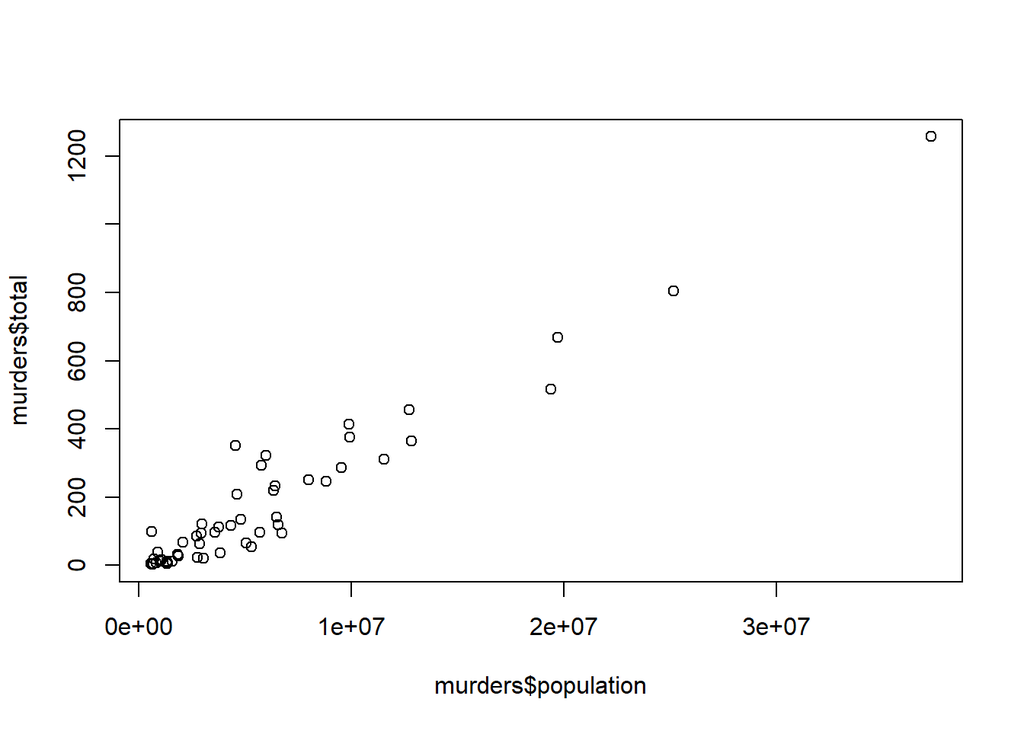

```r
# TODO: interire il codice necesario
plot(murders$population, murders$total)
```

Utilizzare la funzione `plot()` passando una formula (`~`) invece delle due colonne.

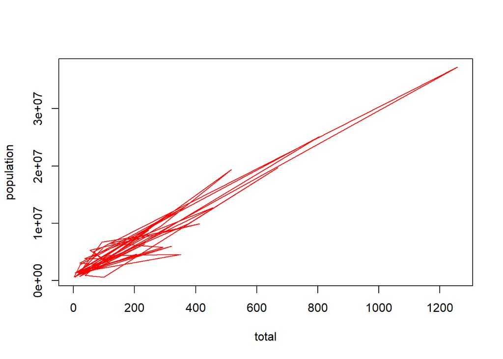

```r
# TODO: interire il codice necesario
plot(population ~ total, data = murders, type = "l", col = "red")
```

Suggerimento: è possibile utilizzare il parametro `log` descritto come

> a character string which contains “x” if the x axis is to be logarithmic, “y” if the y axis is to be logarithmic and “xy” or “yx” if both axes are to be logarithmic.

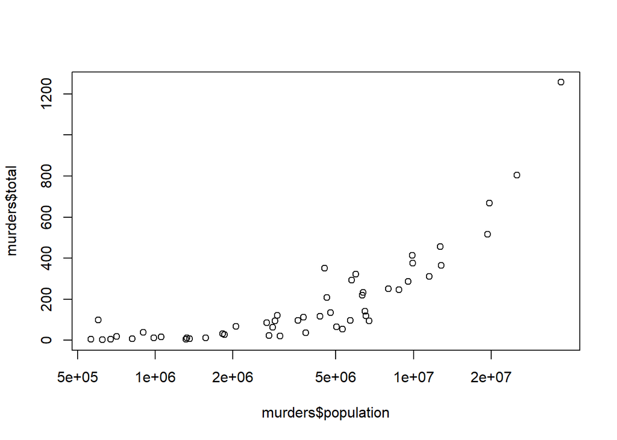

```r
# TODO: interire il codice necesario
#plot(log(murders$population, base = exp(100)), murders$total)
plot(murders$population, murders$total, log="x")
```

Nota: il parametro `log` è descritto nel manuale della funzione `plot.default` che è richiamata da `plot`.

## Istogrammi

Usare la funzione `hist()` per costruire un istogramma del tasso di omicidi.

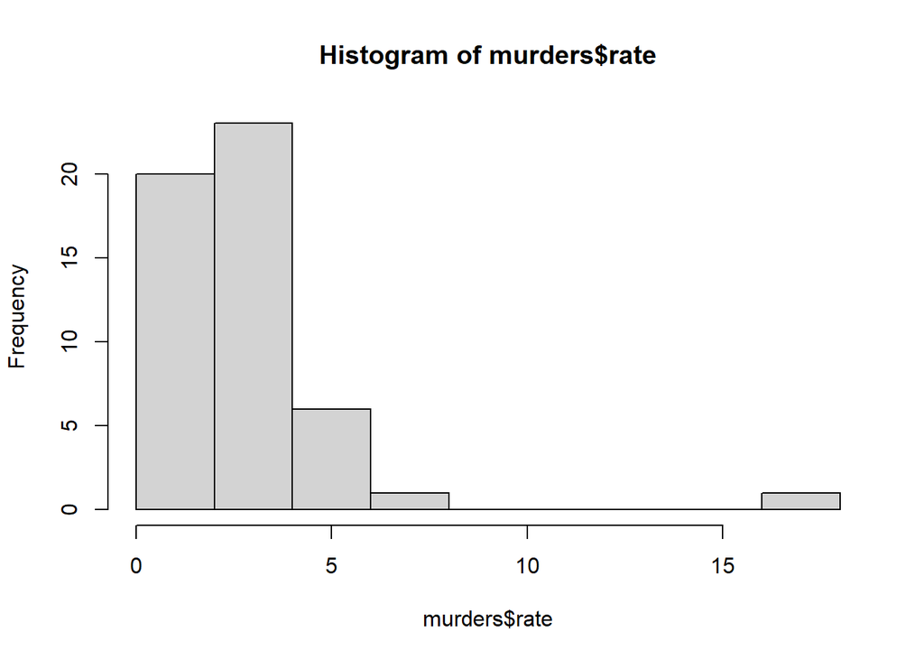

```r
# TODO: interire il codice necesario
hist(murders$rate)
```

Utilizzare il parametro `breaks` che accetta un vettore con i limiti degli intervalli (*bin*) dell’istogramma in modo da utilizzare dei bin di ampiezza 1.

Suggerimento: utilizzare l’operatore range (`:`) per costruire il vettore con i limiti

```r
# TODO: interire il codice necesario
bin <- 0:18
bin
```

```
##  [1]  0  1  2  3  4  5  6  7  8  9 10 11 12 13 14 15 16 17 18
```

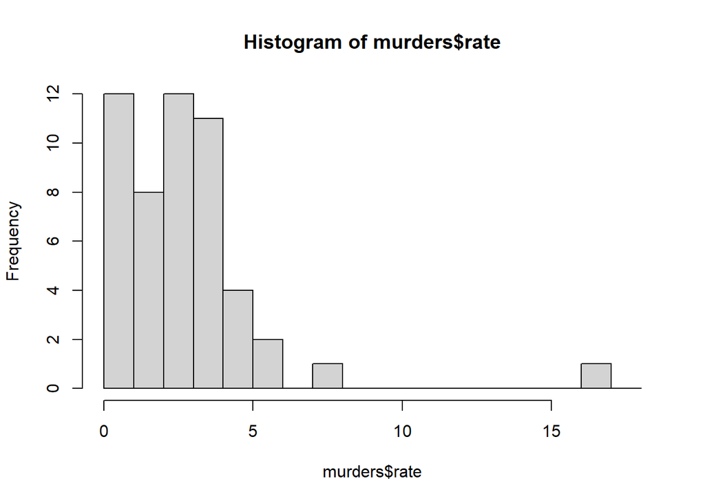

```r
hist(murders$rate, breaks = bin)
```

Come cambia l’istogramma se l’ampiezza dei *bin* è pari a 0.5?

```r
# TODO: interire il codice necesario
bin <- c(0.5:17.5, 0:18)
bin
```

```
##  [1]  0.5  1.5  2.5  3.5  4.5  5.5  6.5  7.5  8.5  9.5 10.5 11.5 12.5 13.5 14.5
## [16] 15.5 16.5 17.5  0.0  1.0  2.0  3.0  4.0  5.0  6.0  7.0  8.0  9.0 10.0 11.0
## [31] 12.0 13.0 14.0 15.0 16.0 17.0 18.0
```

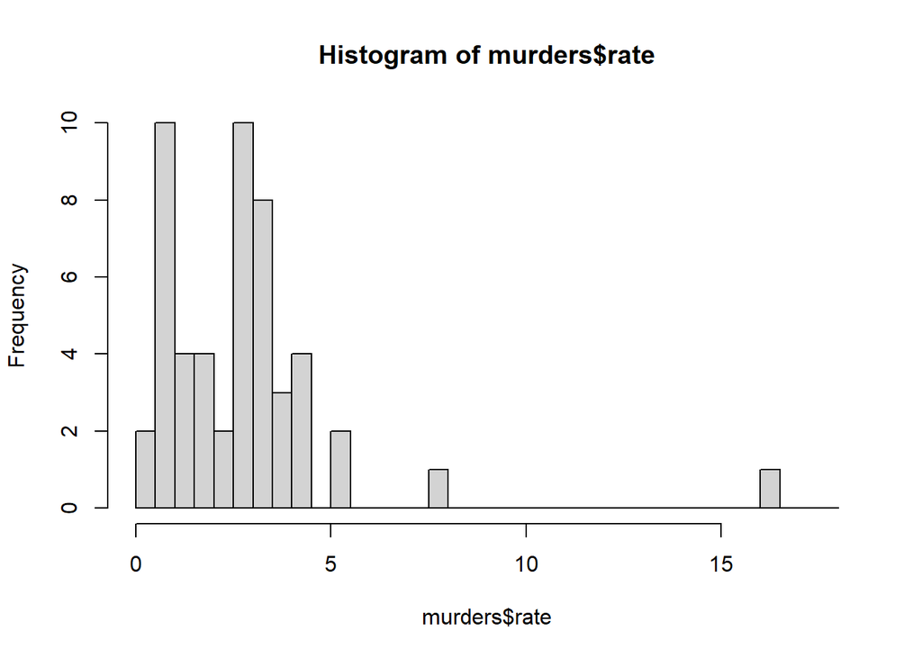

```r
hist(murders$rate, breaks = bin)
```

## Boxplots

Utilizzare un boxplot per rappresentare la distribuzione dei tassi di omicidio.

Suggerimento: si usi la funzione `boxplot()`, è possibile utilizzare il parametro `horizontal` per mostrare il boxplot in orizzontale.

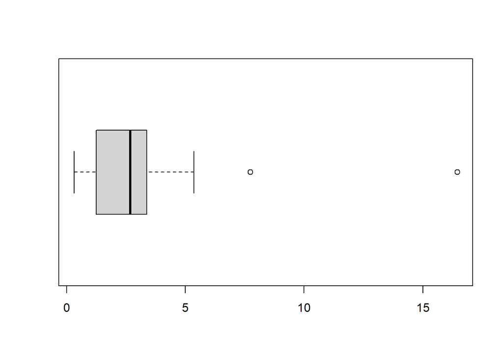

```r
# TODO: interire il codice necesario
boxplot(murders$rate, horizontal = TRUE)
```

Mostrare il confronto tra le distribuzioni dei tassi di omicidio nelle diverse regioni.

Si usi la versione con la formula della funzione `boxplot()`

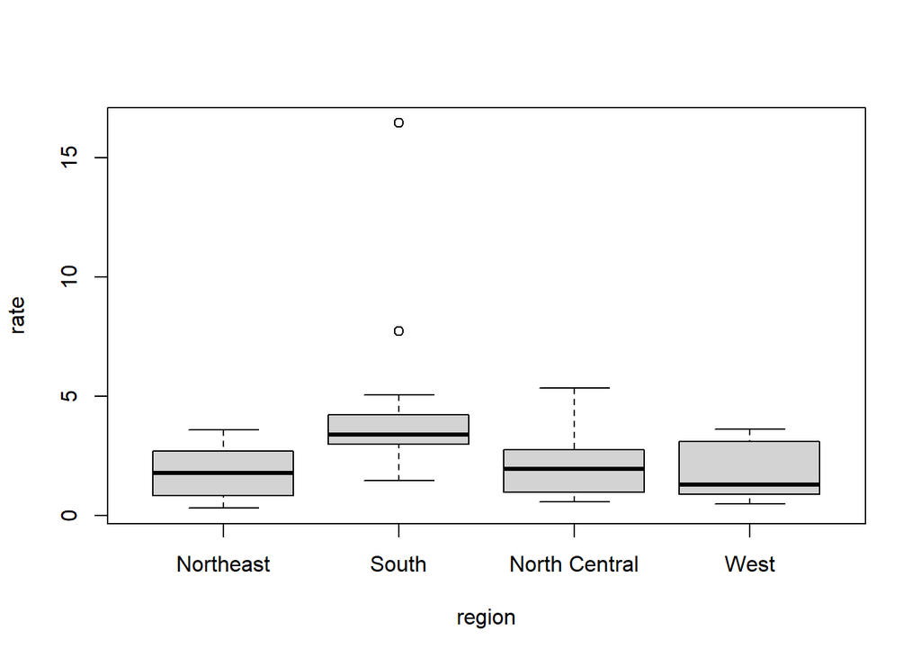

```r
# TODO: interire il codice necesario
boxplot(rate ~ region, data = murders)
```

Osservazione: le diverse regioni sono riportate secondo l’ordine dei livelli del tipo fattore: `levels(murders$region)`.

È possibile cambiare l’ordinamento dei livelli di un fattore tramite la funzione `reorder()` che riceve come parametri: - un vettore di fattori (o che viene convertito in fattore) - un vettore di pari lunghezza i cui valori sono utilizzati per riordinare i livelli - una funzione (opzionale) per aggregare i valori che corrispondono allo stesso livello

Ad esempio per ordinare le regioni in base alla popolazione totale:

```r
murders
```

```
##                   state abb        region population total  rate rating
## 1               Alabama  AL         South    4779736   135  2.82  Medio
## 2                Alaska  AK          West     710231    19  2.68  Medio
## 3               Arizona  AZ          West    6392017   232  3.63   Alto
## 4              Arkansas  AR         South    2915918    93  3.19   Alto
## 5            California  CA          West   37253956  1257  3.37   Alto
## 6              Colorado  CO          West    5029196    65  1.29  Medio
## 7           Connecticut  CT     Northeast    3574097    97  2.71  Medio
## 8              Delaware  DE         South     897934    38  4.23   Alto
## 9  District of Columbia  DC         South     601723    99 16.45   Alto
## 10              Florida  FL         South   19687653   669  3.40   Alto
## 11              Georgia  GA         South    9920000   376  3.79   Alto
## 12               Hawaii  HI          West    1360301     7  0.51  Basso
## 13                Idaho  ID          West    1567582    12  0.77  Basso
## 14             Illinois  IL North Central   12830632   364  2.84  Medio
```

[output cut: 37 more lines]

```r
reor <- reorder(murders$region, murders$population, sum)
reor
```

```
##  [1] South         West          West          South         West
##  [6] West          Northeast     South         South         South
## [11] South         West          West          North Central North Central
## [16] North Central North Central South         South         Northeast
## [21] South         Northeast     North Central North Central South
## [26] North Central West          North Central West          Northeast
## [31] Northeast     West          Northeast     South         North Central
## [36] North Central South         West          Northeast     Northeast
## [41] South         North Central South         South         West
## [46] Northeast     South         West          South         North Central
## [51] West
## attr(,"scores")
##     Northeast         South North Central          West
##      55317240     115674434      66927001      71945553
## Levels: Northeast North Central West South
```

La funzione `sum` viene utilizzata per calcolare un punteggio aggregato (*score*) che poi viene utilizzato per ri-ordinare i livelli

Utilizzando la funzione `reorder()` si mostri un boxplot analogo a quello precedente ma con le regioni ordinate in base al valore medio (funzione `mean`) del tasso di omicidi.

```r
# TODO: interire il codice necesario
reor <- reorder(murders$region, murders$rate, mean)
reor
```

```
##  [1] South         West          West          South         West
##  [6] West          Northeast     South         South         South
## [11] South         West          West          North Central North Central
## [16] North Central North Central South         South         Northeast
## [21] South         Northeast     North Central North Central South
## [26] North Central West          North Central West          Northeast
## [31] Northeast     West          Northeast     South         North Central
## [36] North Central South         West          Northeast     Northeast
## [41] South         North Central South         South         West
## [46] Northeast     South         West          South         North Central
## [51] West
## attr(,"scores")
##     Northeast         South North Central          West
##      1.847778      4.415882      2.182500      1.833077
## Levels: West Northeast North Central South
```

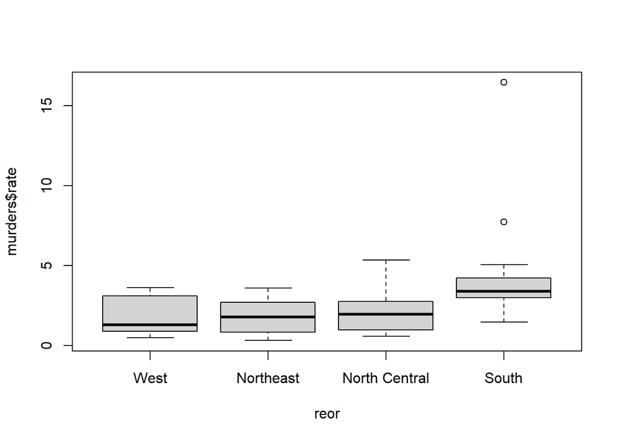

```r
boxplot(murders$rate ~ reor)
```

## Diagrammi a barre

Suggerimento: si usi la versione con la formula ed impostare il parametro `horiz` a `TRUE` per avere le barre orizzontali ed il parametro `las` a 1 per avere le etichette orizzontali.

NB: sono stati impostati i parametri `fig.width` e `fig.height` del chunk per garantire un corretto rapporto altezza/larghezza

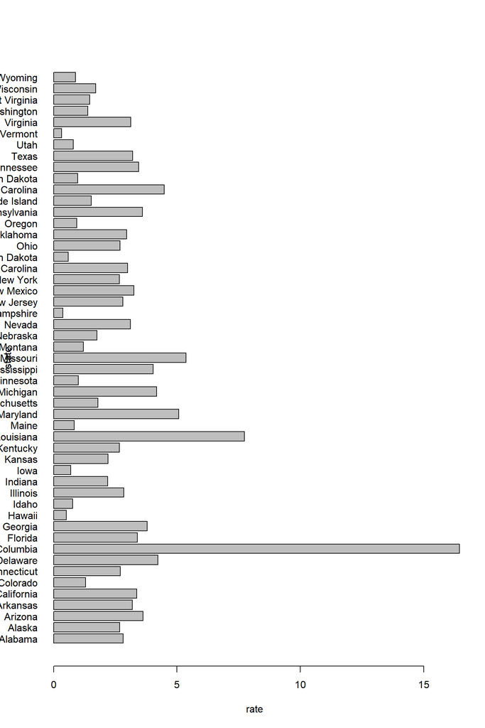

```r
# TODO: interire il codice necesario
barplot(rate ~ state, data = murders, horiz = TRUE, las = 1)
```

Osservazione: le etichette (di tipo `character`) sono mostrate in ordine alfabetico con il primo elemento del nella posizione più prossima all’asse orizzontale (quindi in basso).

Suggerimento: la funzione `reorder()` trasforma in fattore il primo parametro se questo non lo è, poi riordina i fattori.

```r
# TODO: interire il codice necesario
reor2 <- reorder(murders$state, - murders$rate, sum)
reor2
```

```
##  [1] Alabama              Alaska               Arizona
##  [4] Arkansas             California           Colorado
##  [7] Connecticut          Delaware             District of Columbia
## [10] Florida              Georgia              Hawaii
## [13] Idaho                Illinois             Indiana
## [16] Iowa                 Kansas               Kentucky
## [19] Louisiana            Maine                Maryland
## [22] Massachusetts        Michigan             Minnesota
## [25] Mississippi          Missouri             Montana
## [28] Nebraska             Nevada               New Hampshire
## [31] New Jersey           New Mexico           New York
## [34] North Carolina       North Dakota         Ohio
## [37] Oklahoma             Oregon               Pennsylvania
## [40] Rhode Island         South Carolina       South Dakota
## [43] Tennessee            Texas                Utah
## [46] Vermont              Virginia             Washington
## [49] West Virginia        Wisconsin            Wyoming
## attr(,"scores")
##              Alabama               Alaska              Arizona
##                -2.82                -2.68                -3.63
##             Arkansas           California             Colorado
##                -3.19                -3.37                -1.29
##          Connecticut             Delaware District of Columbia
##                -2.71                -4.23               -16.45
##              Florida              Georgia               Hawaii
##                -3.40                -3.79                -0.51
##                Idaho             Illinois              Indiana
##                -0.77                -2.84                -2.19
##                 Iowa               Kansas             Kentucky
##                -0.69                -2.21                -2.67
##            Louisiana                Maine             Maryland
##                -7.74                -0.83                -5.07
##        Massachusetts             Michigan            Minnesota
##                -1.80                -4.18                -1.00
##          Mississippi             Missouri              Montana
##                -4.04                -5.36                -1.21
##             Nebraska               Nevada        New Hampshire
##                -1.75                -3.11                -0.38
##           New Jersey           New Mexico             New York
##                -2.80                -3.25                -2.67
##       North Carolina         North Dakota                 Ohio
##                -3.00                -0.59                -2.69
##             Oklahoma               Oregon         Pennsylvania
##                -2.96                -0.94                -3.60
##         Rhode Island       South Carolina         South Dakota
##                -1.52                -4.48                -0.98
##            Tennessee                Texas                 Utah
##                -3.45                -3.20                -0.80
##              Vermont             Virginia           Washington
##                -0.32                -3.12                -1.38
##        West Virginia            Wisconsin              Wyoming
##                -1.46                -1.71                -0.89
## 51 Levels: District of Columbia Louisiana Missouri Maryland ... Vermont
```

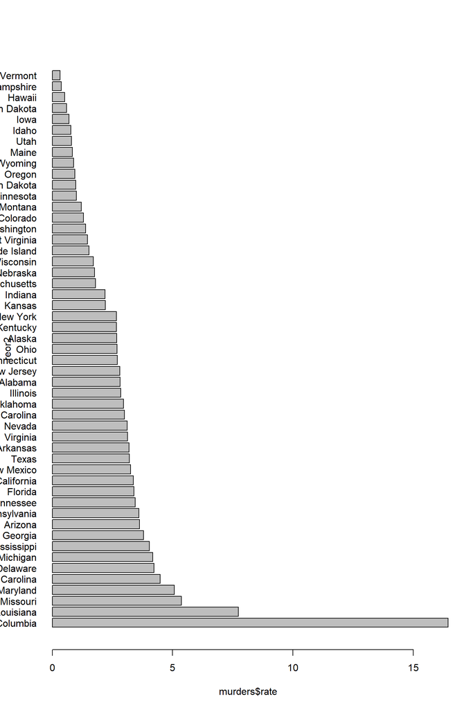

```r
barplot(murders$rate ~ reor2, horiz = TRUE, las = 1)
```